# First Project: Douglas Color Cards

Ana Maria Sandoval Jimenez, Jannis Busch & Sabrina Steinert

May 22, 2018

## Introduction

### The Data

The following report is based on two given data files both in csv format. They generally contain color code measurements of the Douglas Color Cards (DCC). The DCC are used in combination with a mobile App. The consumer takes a photo holding the DCC close to their face. With the help of the app, the correct foundation nuance is recommended based on the skin color results.

[figure not shown]

**The first data file** (MasterColorCard.csv) contains the “perfect” DCC as it should always be with color codes in CMYK and Lab space. The resulting dataframe from the csv file consists of 64 rows (each color spot is represented as one row) and 11 columns.

```r
dim(master)
```

```
## [1] 64 11
```

```r
names(master)
```

```
##  [1] "Field" "Crow"  "Ccol"  "p1"    "p2"    "p3"    "p4"    "p5"
##  [9] "L"     "a"     "b"
```

Each of the 64 color spots on the master DCC has a specific position, that is described in columns Crow and Ccol.

**The second data file** (LabMeasurements-Color-Card.csv) is larger than the first data set because it contains several color spot measurements from multiple color cards which have been printed on 13 print sheets. Put into a dataframe, the data is clearly in wide format which means that the color spots are not depicted in rows but rather obtain three columns (L-a-b).

```r
dim(lab)
```

```
## [1] 546 194
```

**13** printing sheets **x 42** color cards on each printing sheet **= 546** rows

In conclusion, each row in this dataframe depicts one complete DCC which has been measured in the lab. The file also contains the position on the printing sheet as in row and column. Therefore every row/column combinations exists 13 times.

### The Task

The task is to make sense out of the given data sets and explore what conclusions can be drawn. The objective is to use a variety of calculations and visualization techniques to find those explanations for the given data.

### The Tools

In the process of the group work, we have been using Github and R Studio. With Github we were able to share our R scripts in an anonymized manner. R Studio has been the choice of our local working environment due to the fact that all lectures have been complemented with R Studio. Hence the environment was known to each team member.

### What We Expect

Upon first looks into the data, we expect to find DCCs from the lab that vary a lot from the Master DCC in color space given in L-a-b values. We will explore these differences using multiple visualization techniques that have been subject in current lectures including Data Visualization and Machine Learning.

## Data Exploration and Findings

To have a first overview of the master DCC data, a 3-dimensional scatterplot was created. The following code produces one in the L-a-b space with each spot represented in the respective color on the master DCC.

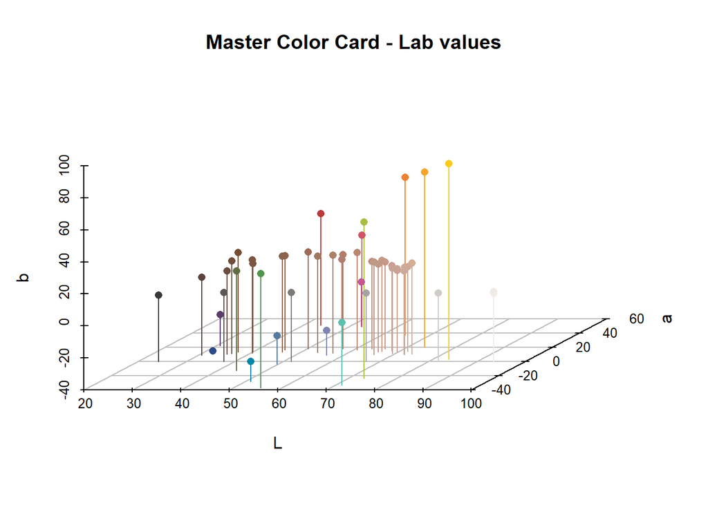

```r
# save L, a and b values from dataframe to vectors
Lstar = master$L
Astar = master$a
Bstar = master$b

# create new dataframe from L-a-b vectors
solarized = structure(list(Lstar, Astar, Bstar), .Names = c("Lstar", "Astar", "Bstar"), row.names = c(NA,16), class = "data.frame")
solarizedLAB = with(solarized, LAB(Lstar, Astar, Bstar))

# show us all 64 color spots in a L-a-b plot coloured in their LAB color
s3d <- scatterplot3d(master[,9:11],
              main="Master Color Card - Lab values",
              color = hex(solarizedLAB, fixup = TRUE),
              pch = 16,
              type = "h",
              grid=TRUE,
              box=FALSE)
```

### K-Means Clustering

After an initial feeling for the master DCC, one way to visually access the lab data is to cluster each of the 546 DCC.

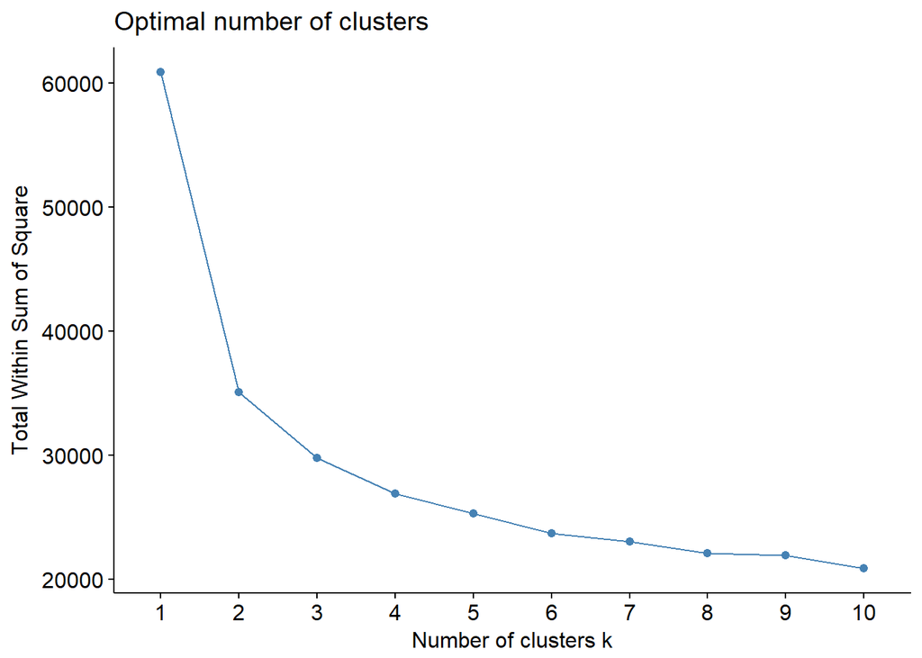

```r
# function will determine best k via elbow method
fviz_nbclust(lab, kmeans, method = "wss")
```

The elbow is visible at “Number of clusters k” = 3, where the Sum of Squares falls rapidly for the last time. Hence we will choose the K-means clustering with 3 clusters and plot them for the first two principal components.

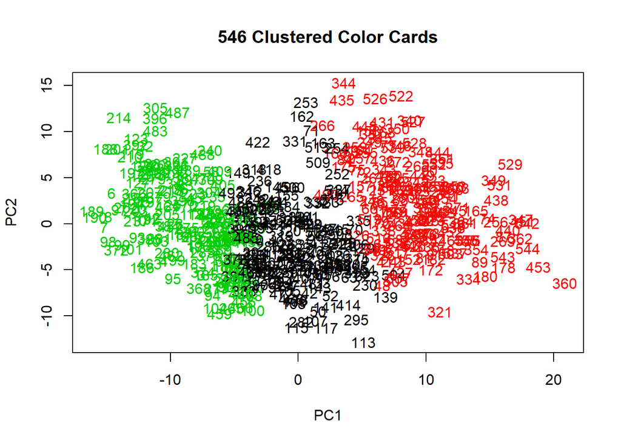

```r
# Run a K-means clustering with 3 clusters and plot the clusters for first 2 principal components
km.out<-kmeans(lab,centers=3,nstart=1) #run with four clusters
pr.out<-prcomp(lab,scale=TRUE)
plot(pr.out$x[,1:2],type="n", main="546 Clustered Color Cards", ylab="PC2")
text(pr.out$x[,1:2],col=km.out$cluster)
```

### MDS

The main goal of MDS it is to plot multivariate data points in two dimensions, thus revealing the structure of the dataset by visualizing the relative distance of the observations.

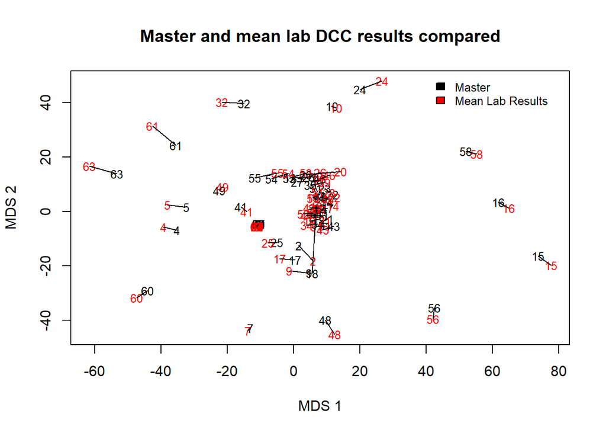

```r
# Plot the master card's color spots with their field number labels into a 2D space
master <- as.matrix(master)[, 9:11]
mds <- cmdscale(dist(master))

# Plot the labs means of all color spots with their field number labels into a 2D space
# calculate the lab measurements means
mlab <- colMeans(x = lab)
mlab <- as.matrix(mlab)[3:194]
mlab <- t(mlab)
mlab <- as.data.frame(matrix(unlist(mlab, use.names=FALSE),ncol=3, byrow=TRUE))
colnames(mlab) <- c("L", "a", "b")
mlab <- as.matrix(mlab)
mds.ml <- cmdscale(dist(mlab))

# Plot both (master and mean lab results) into one space
plot(mds.ml, type = 'n', main="Master and mean lab DCC results compared", xlab="MDS 1", ylab="MDS 2")
text(mds[, 1], mds[, 2], cex=0.8) # master
text(mds.ml[, 1], mds.ml[, 2], col="red", cex=0.8) # lab means
legend(x = 40 , y = 51,
       legend = c("Master", "Mean Lab Results"),
       fill = c("black", "red"),
       bty = "n",
       cex = 0.8)

# add connecting lines into plot
segments(mds[, 1], mds[, 2], mds.ml[, 1], mds.ml[, 2] ,col = par("fg"), lty = par("lty"), lwd = par("lwd"))
```

The MDS plot visualizes the master data points (black) values in a 2d plot and their distance to the mean of all color spots from the lab results (red). The position of the numbers in the plot is derived from their L-a-b color spot values. The numbers in the plot are the respective color spot with labels from 1 to 64. One can see from this plot that there are lab result color spots that are more different than the actual master color spot l-a-b color value. Visibly different are color spots 8 with the visually greatest distance from the master color spot as well as 61 and 63. It makes sense to have a closer look into this difference on a detailed level (and not on the “mean over all lab results” scale) which is what we are doing in the following visualisations.

### CIE76

The CIE76 deltaE was used in order to obtain an easy-to-calculate color measurement; the Euclidian distance is used for determining color distance.

using:
$$({L_{1}^{*}},{a_{1}^{*}},{b_{1}^{*}})$$
and
$$({L_{2}^{*}},{a_{2}^{*}},{b_{2}^{*}}),$$
two colors in L-a-b:

$$\Delta E_{ab}^{*}={\sqrt {(L_{2}^{*}-L_{1}^{*})^{2}+(a_{2}^{*}-a_{1}^{*})^{2}+(b_{2}^{*}-b_{1}^{*})^{2}}}$$

```r
deltae <- matrix(NA,nrow = 546, ncol=66, byrow = TRUE)
deltae[,1] <- lab[,1];
deltae[,2] <- lab[,2];

# colnames(deltae)
colnames(deltae) <- c("Row", "Column", c(11:18, 21:28, 31:38, 41:48, 51:58, 61:68, 71:78, 81:88))

distance_single <- {}
distance_row <- {}


for (i in 1:length(row.names(lab))) {
    cardmatrix <- matrix(lab[i,-c(1:2)],nrow=64,ncol=3,byrow=TRUE)
    colnames(cardmatrix) = c("L","a","b")
    for (j in 1:64) {
        cardmatrix[j,] -> matrixA
        master[j,] -> matrixB
        distance_single <- sqrt((matrixA$L - matrixB$L)^2 + (matrixA$a - matrixB$a)^2 + (matrixA$b - matrixB$b)^2)
        distance_row[j] <- distance_single
    }
    deltae[i,-c(1:2)] <- distance_row
}
```

The following histogram shows the frequency of all eucledean distances between each master DCC color spot and each corresponding lab result color spot.

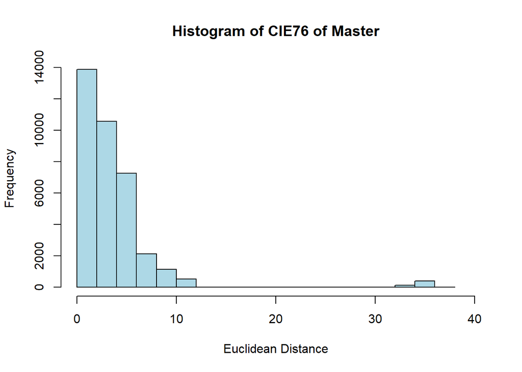

```r
hist(deltae, #breaks = 20,
     xlim = range(0:40),#c(0,40),
     main = paste("Histogram of" , 'CIE76', "of Master"),
     ylim = NULL,
     xlab = 'Euclidean Distance', ylab = 'Frequency', col = 'lightblue',
     #axes = FALSE,
     plot = TRUE, labels = FALSE)
```

```r
CIE76 <- deltae
colorMean <- apply(CIE76[,3:66],2,mean)
colors_jnd <- {}
for (i in c(1:64)) {
  x <- colorMean[i]
  if (x < 1)                # Unnoticable to the human eye
    colors_jnd[i] = 1
  else if (1 < x && x < 2)  # barely noticable
    colors_jnd[i] = 2
  else if (2 < x && x < 4)  # noticable difference on a keen eye
    colors_jnd[i] = 3
  else if (4 < x )          # clearly distinct
    colors_jnd[i] = 4
}

mean_matrix <- matrix(colors_jnd, nrow = 8, ncol= 8, byrow = TRUE, dimnames = NULL)
```

Depicted in a 8x8 heatmap that contains all 64 color spots, one can now see which color spots differ the most between master and lab results.

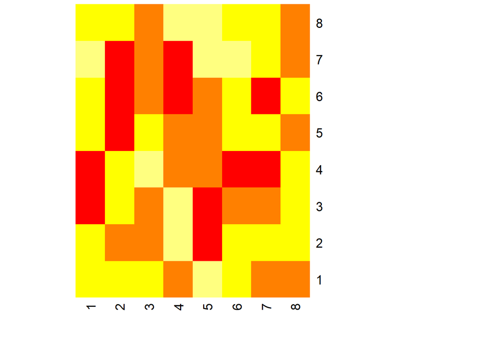

```r
# heatmap with col = heatmap()
mean_heatmap <- heatmap(mean_matrix, Rowv=NA, Colv=NA, col = heat.colors(4, alpha=1),
                       scale="column", margins=c(5,10))
```

## CIE94

The CIE94 deltaE was used in order to obtain a more advanced mesasurement on the differences among colors. CIE94 was introduced in 1994 as an extension to the formerly established CIE76. It’s basic structure is similar to CIE76 in that it uses the Euclidean Distance, though it includes additional weighting factors to account for application specific differences in perception. According to Wikipedia: “CIE94 addresses perceptual non-uniformities, while retaining the L*a*b* color space, by the introduction of application-specific weights derived from an automotive paint test’s tolerance data.”

$$({L_{1}^{*}},{a_{1}^{*}},{b_{1}^{*}})$$
and
$$({L_{2}^{*}},{a_{2}^{*}},{b_{2}^{*}}),$$
two colors in L*a*b*:

$$\Delta E_{94}^{*}={\sqrt {(\frac{\Delta L^{*}}{k_{L}S_{L}})^{2}+(\frac{\Delta C_{ab}^{*}}{k_{C}S_{C}})^{2}+(\frac{\Delta H_{ab}^{*}}{k_{H}S_{H}})^{2}}}$$
In detail, the equation consists of the following sub-operations:
$$\Delta L^{*} = L_1^{*} - L_2^{*}\\
C_1^* = {\sqrt {a_1^{*2} + b_1^{*2}}}\\
C_2^* = {\sqrt {a_2^{*2} + b_2^{*2}}}\\
\Delta C_{ab}^{*} = C_1^* - C_2^*\\
\Delta H_{ab}^* = {\sqrt {{{\Delta E_{ab}^{*}}^2} - {\Delta L^*}^2 - {{\Delta C_{ab}^{*}}^2}}} = {\sqrt {{{\Delta a^{*}}^2} + {\Delta b^*}^2 - {{\Delta C_{ab}^{*}}^2}}}\\
\Delta a^* = a_1^* - a_2^*\\
\Delta b^* = b_1^* - b_2^*\\
S_L = 1\\
S_C = 1 + K_1C_1^*\\
S_H = 1 + K_2C_1^*\\
k_L = 1\\
K_1 = 0.045; K_2 = 0.015$$

The matrix consisting of the differences between every single one of the pixels from the printed cards versus the master color data resulted in a similar outcome as the CIE76 comparison provided.

```r
# function to compute the distances based on Lab1 and Lab2
labDistance <- function(L1,a1,b1,L2,a2,b2) {
  # collection of all values from CIE94
  dL <- L1 - L2
  C1 <- sqrt((a1)^2 + (b1)^2)
  C2 <- sqrt((a2)^2 + (b2)^2)
  dC <- C1-C2
  da <- a1 - a2
  db <- b1 - b2
  dH <- sqrt(da^2 + db^2 - dC^2)
  Sl <- 1
  kL <- 1
  K1 <- 0.045
  K2 <- 0.015
  Sc <- 1 + K1*C1
  Sh <- 1 + K2*C1

  # final distance value
  dE <- sqrt((dL/(kL * Sl))^2 + (dC/Sc)^2 + (dH/Sh)^2)
  return(dE)
}
```

## Comparing CIE76 vs CIE94

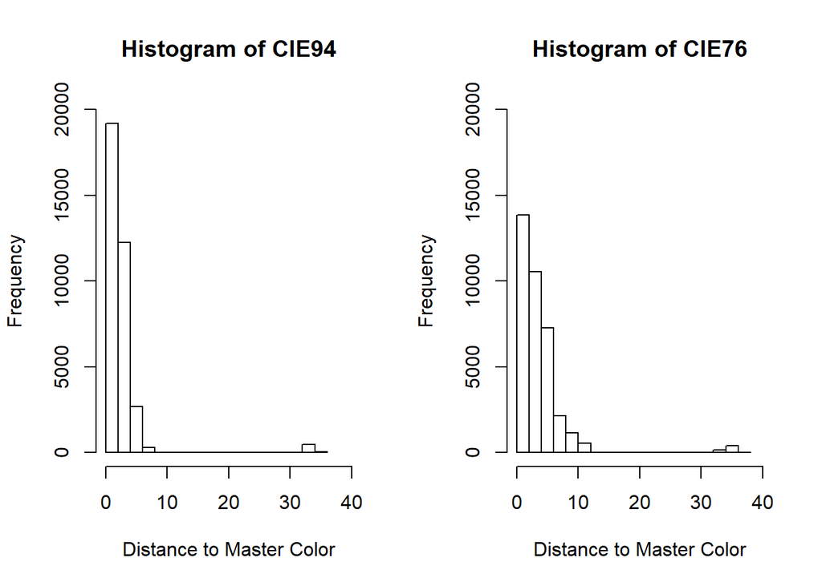

By plotting the average differences of the distance values comparing the mean results of CIE76 vs CIE94 it is to be concluded that there is only a marginal difference between the two methods.Comparing the results of CIE76 and CIE94 in a scatterplot reveals that in general the measured distances appear larger in CIE76 versus CIE94.

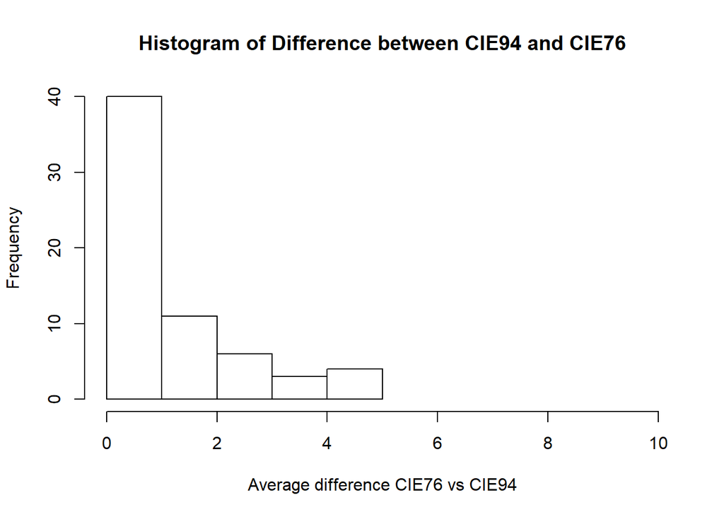

```r
# compare dimensions
# dim(CIE76); dim(CIE94)

# subtract the deltaes of CIE94 off the deltaes of CIE76 to analyse the differences between both equations (dd, the double d stands for double deltae!)
dd <- CIE76[,3:66] - CIE94[,3:66]
# calculate means of the double deltae and the total mean of everything
dd.means <- apply(dd, 2, mean)
dd.mean <- mean(dd.means)
dd.max <- max(dd)

# do the same to the original two dataframes
# CIE76
CIE76.means <- apply(CIE76[,3:66], 2, mean)
CIE76.mean <- mean(CIE76.means)
CIE76.max <- max(CIE76[,3:66])

# CIE94
CIE94.means <- apply(CIE94[,3:66], 2, mean)
CIE94.mean <- mean(CIE94.means)
CIE94.max <- max(CIE94[,3:66])

# plot histograms of CIE76, CIE94 data and the double d in same scale for comparison
hist(dd.means, breaks = 5, xlim = c(0,10), xlab="Average difference CIE76 vs CIE94", main="Histogram of Difference between CIE94 and CIE76")
```

Comparing the mean results of CIE76 and CIE94 in a scatterplot reveals that in general the measured distances appear larger in CIE76 versus CIE94. Not a single color has been measured with a larger difference on average with CIE94 than it was calculated with CIE76, as the line represents the unity vector through the origin.

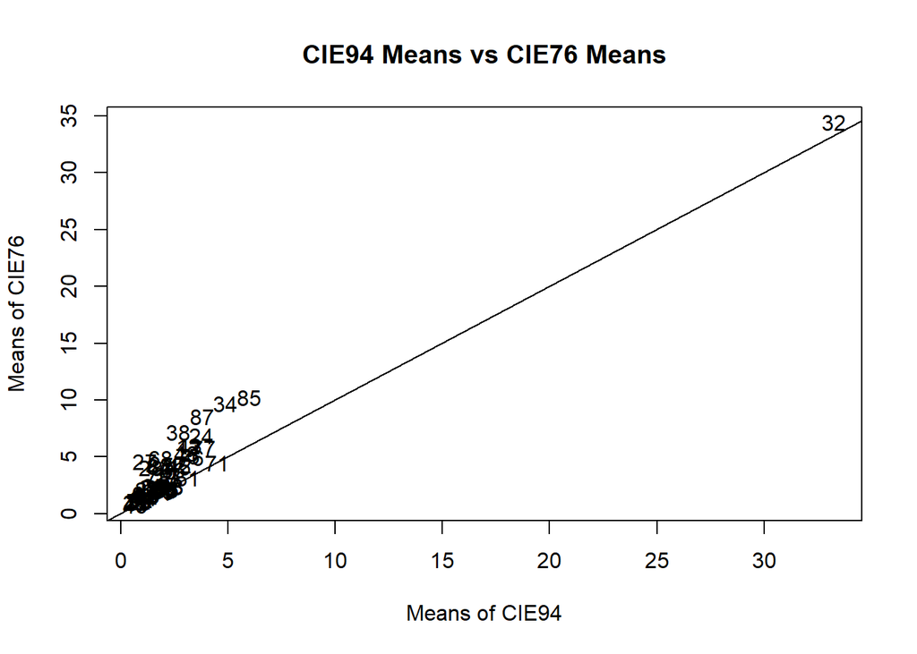

```r
# plotting means of cIE94 against CIE76
par(mfrow=c(1,1))
plot(CIE76.means ~ CIE94.means, type="n", main="CIE94 Means vs CIE76 Means", xlab="Means of CIE94",ylab="Means of CIE76")
# add line for comparing level of identity
abline(a=0, b=1)
text(CIE94.means, CIE76.means, labels=colnames(CIE94[3:66]))
```

```r
t.test(CIE94.means,CIE76.means)
```

```
##
##  Welch Two Sample t-test
##
## data:  CIE94.means and CIE76.means
## t = -1.4549, df = 124.89, p-value = 0.1482
## alternative hypothesis: true difference in means is not equal to 0
## 95 percent confidence interval:
##  -2.5707151  0.3924517
## sample estimates:
## mean of x mean of y
##  2.599584  3.688716
```

## Master Pixels against the Largest Distance Pixels

In order to “see” the scope of differences among the pixels in the color cards, we identify the pixels of each of the 546 cards with the largest difference to the respective pixel in the master card. We then reproduce a “card of maximum distances” and compare it against the original master card. The colors have been transformed from Lab values to their respective hexadecimal values to plot them in R.

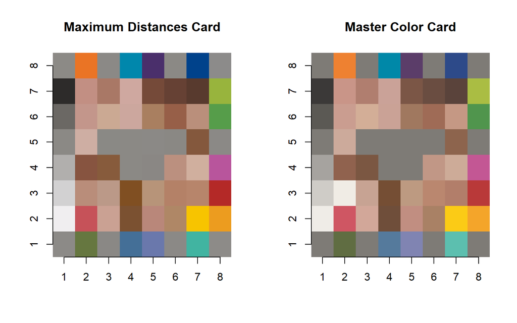

```r
# attach sheet numbers to distance deltae data frame
sheet.number <- {}
k <- 1
for (i in 1:546) {
  if (k>13) {
    k <- 1
  }
  sheet.number[i] <- k
  k <- k +1
}
CIE94 <- cbind(sheet.number, CIE94)

# identify cell with the largest distance between lab and master color
#CIE94[which.max(apply(CIE94,1,max)), which.max(apply(CIE94,2,max))]
# extract row and column values
max.color <- c(which.max(apply(CIE94,1,max)), which.max(apply(CIE94,2,max)))
# extract column name i.e. color card pixel position
pixel.number <- colnames(CIE94[max.color[2]])
# extract sheet number
sheet.number <- CIE94[max.color[1], 1]
# build column name, e.g. "L12", "a42"
col1 <- paste(c("L", pixel.number), collapse = "")
col2 <- paste(c("a", pixel.number), collapse = "")
col3 <- paste(c("b", pixel.number), collapse = "")
# collect Lab value
Lab <- c(lab.measure[max.color[1],col1], lab.measure[max.color[1],col2], lab.measure[max.color[1],col3])
# transform Lab value to hexadecimal color
lab.hex <- hex(LAB(Lab[1],Lab[2],Lab[3]), fixup = T)
# create hexadecimal color of master card
master.hex <- hex(LAB(master.color[which(master.color$Crow == 3 & master.color$Ccol == 2), "L"],master.color[which(master.color$Crow == 3 & master.color$Ccol == 2), "a"],master.color[which(master.color$Crow == 3 & master.color$Ccol == 2), "b"]), fixup=T)

allMax <- matrix(NA,nrow = 64, ncol=3, byrow = TRUE)
for (i in 4:67) {
  allMax[i-3, 1] <- which.max(CIE94[,i])
  allMax[i-3, 2] <- i-3
  allMax[i-3, 3] <- max(CIE94[,i])

}

# function to display a color card. Expects a distance matrix of 64:2,
# with rowvalue being the row value of CIE94 and column value being the column value of CIE94 (as in 3~13,64~88)
colorcardDisplay <- function(pixels){
  pixel.numbers <- matrix(NA, nrow=64, ncol=1, byrow=TRUE)
  for (i in 1:64){
    pixel.numbers[i,1] <- colnames(CIE94[pixels[i, 2]+3])
  }
  pixels <- cbind(pixels, pixel.numbers)

  pixel.hex <- matrix(NA, nrow=64, ncol=2, byrow=T)
  for (i in 1:64){
    col1 <- paste(c("L", pixels[i,4]), collapse = "")
    col2 <- paste(c("a", pixels[i,4]), collapse = "")
    col3 <- paste(c("b", pixels[i,4]), collapse = "")
    Lab <- c(lab.measure[pixels[i,1],col1], lab.measure[pixels[i,1],col2], lab.measure[pixels[i,1],col3])
    lab.hex <- hex(LAB(Lab[1],Lab[2],Lab[3]), fixup = T)
    pixel.hex[i,1] <- pixels[i,3]
    pixel.hex[i,2] <- lab.hex
  }
  image(matrix(1:64,nrow=8),col=pixel.hex[,2],main="Maximum Distances Card",xlab="",ylab="", axes= FALSE)
  axis(side=1, at=seq(from=0,to=1,length.out=8),labels=c(1:8))
  axis(side=2, at=seq(from=0,to=1,length.out=8),labels=c(1:8))
}

# function to display the master color card. No inputs expected
mastercardDisplay <- function(){
  master.hex <- matrix(NA,nrow=64,ncol = 1,byrow=T)
  for(i in 1:64){
    master.hex[i,1] <- hex(LAB(master.color[i, "L"],master.color[i, "a"],master.color[i, "b"]), fixup=T)
  }
  image(matrix(1:64,nrow=8),col=master.hex[,1],main="Master Color Card",
        xlab="",ylab="", axes= FALSE)
  axis(side=1, at=seq(from=0,to=1,length.out=8),labels=c(1:8))
  axis(side=2, at=seq(from=0,to=1,length.out=8),labels=c(1:8))
}
par(mfrow=c(1,2))
colorcardDisplay(allMax)
mastercardDisplay()
```